# Análise Dados

Mori, Danilo

19/11/2022

# MNEE com mapas contemporaneos

### Qual a relação entre o número de SADs congruentes segundo o teste KS e o teste DTS?

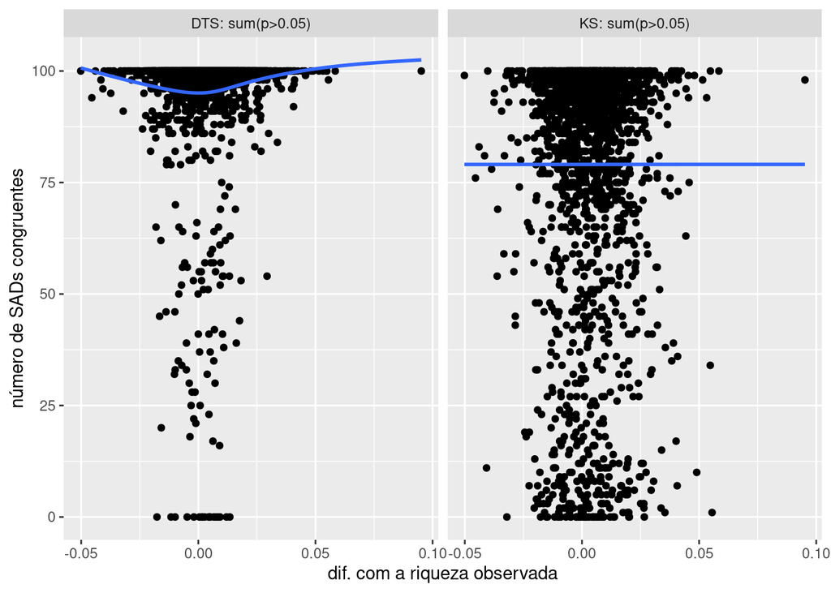

**Figura 1** Número de SADs congruentes (y) em função da diferença da riqueza da réplica e da SAD observada ( (Sobs - Srep )/ Sobs) por tipo de teste (DTS e KS).

DECISÕES:

1. ambos os testes apresentam erro pequeno quando a hipótese nula é verdadeira (comparação de réplicas de uma mesma bateria de simulação).
   2. o teste DTS apresenta um erro maior quando a hipótese nula é falsa (comparação de réplicas de um mesmo sítio quando k=0.99 e k=0.05), porém o teste KS apresenta um erro de 47%; ainda vou mostrar para o PI esses resultados, talvez precise complementar essa segunda comparação.

      CONCLUSÃO) Minha decisão é continuar com o teste KS pois no visual ele se sai melhor, apesar de ambos apresentarem problemas.

### Gráficos Exploratórios

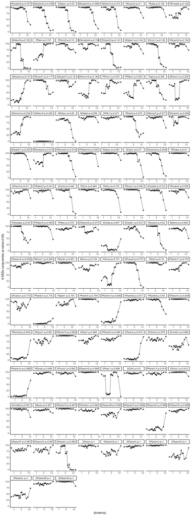

**Figura 2** Número de SADs congruentes (p-value>0.05) pela desvio padrão da função de dispersão (metros) por sítio de amostragem. Os paineis estão organizados pela proporção de cobertura vegetal (p).

Notas:

1. em PEmata2 a melhora na congruência em cenários de limitação mais brandos pode ser considerada um erro dos testes, na verdade pode ser considerado que existe uma piora? Lembre-se que pelo artigo do teste DTS a maior variabilidade existe justamente nos valores intermediários.
2. em outros casos acontece o mesmo tipo de erro: nas áreas que mais chama a atenção é aquela em que pode existir maior variabilidade. Penso se isso não deveria aumentar o número de SADs réplicas.

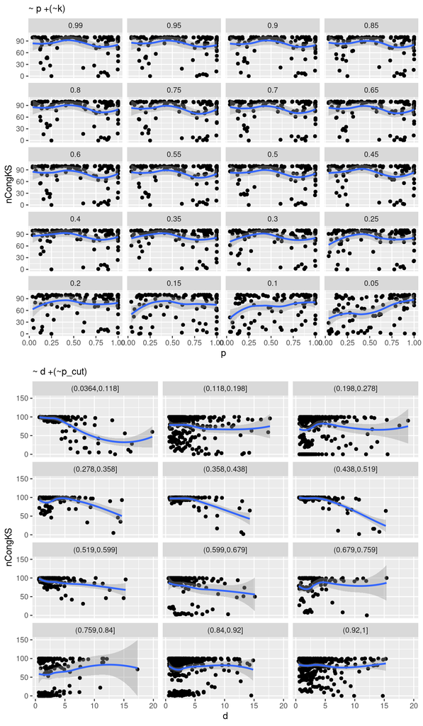

**Figura 3** gráficos exploratórios efeitos fixos

### Seleção da estrutura aleatória e variável de dispersão

**Tabela 1** Peso de evidência dos modelos cheios

```
##                          dAICc   df weight
## k_cont^2 + k_cont^2|Site     0.0 15 1
## k + 1|Site               26136.2 61 <0.001
## k_cont^2 + 1|Site        28103.5 10 <0.001
```

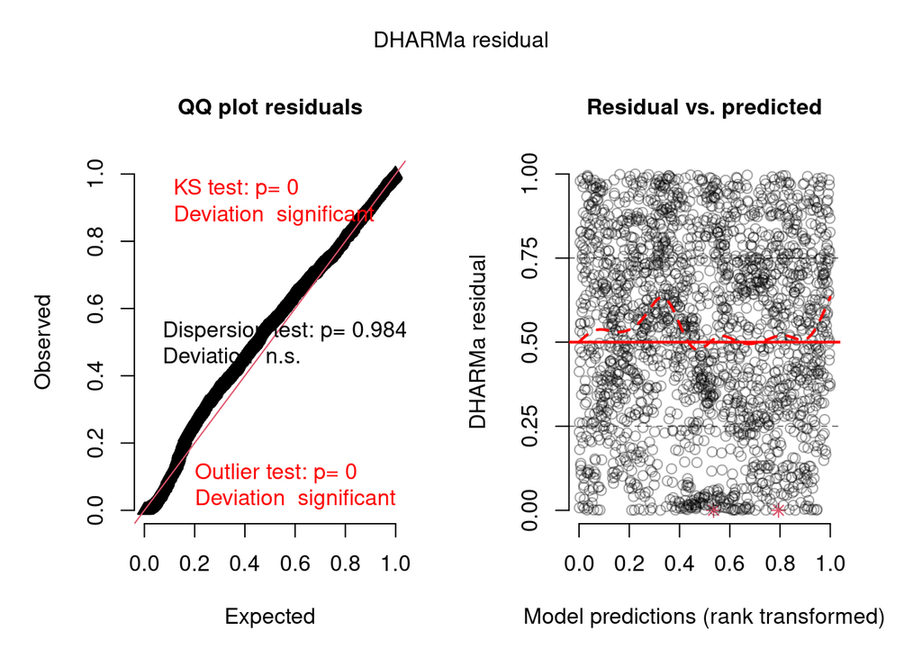

**Figura 4** Resíduos Quantílicos modelo cheio selecionado MNEE nCongKS

**Tabela 1** Coeficiente de determinação marginal e condicional do modelo cheio selecionado para nCongKS de MNEE

|  | R2m | R2c |
| --- | --- | --- |
| theoretical | 0.0494634 | 0.9957837 |
| delta | 0.0493864 | 0.9942335 |